# 01_23_report2

Siyang Ni

2023-01-23

## Variables Addressed

All of them are in DS3 sub dataset, where all delinquency variables are:

V2105: On how many occasions (if any) have you had alcoholic beverages to drink–more than just a few sips . . . during the last 12 months?

V2116: On how many occasions (if any) have you used marijuana (grass, pot) or hashish (hash, hash oil) . . . during the last 12 months?

V2119: On how many occasions (if any) have you used LSD (“acid”) . . . during the last 12 months?

V2125: On how many occasions (if any) have you taken cocaine (sometimes called “coke”, “crack”, “rock”) . . . during last 12 months?

V2128: On how many occasions (if any) have you taken amphetamines on your own–that is, without a doctor telling you to take them . . . during the last 12 months?

V2134: On how many occasions (if any) have you taken sedatives on your own–that is, without a doctor telling you to take them . . . during the last 12 months?

V2137: On how many occasions (if any) have you taken tranquilizers on your own–that is, without a doctor telling you to take them . . . during the last 12 months?

V2140: On how many occasions (if any) have you taken heroin . . . during the last 12 months?

V2143: On how many occasions (if any) have you taken narcotics other than heroin on your own–that is, without a doctor telling you to take them . . . during the last 12 months?

V2146: On how many occasions (if any) have you sniffed glue, or breathed the contents of aerosol spray cans, or inhaled any other gases or sprays in order to get high . . . during the last 12 months?

V2581: On how many DAYS (if any) have you vaped NICOTINE . . . during the last 12 months?

## Note

For every variable, *Column %(NA-)* reports the frequency without any NAs. I also reported the cumulative frequency in column cum.%(NA-).

I also plotted the frequency for each variable, giving a more intuitive way of digesting the frequency information. All NAs are indicated by the “last” bar of the histogram, unless otherwise indicated.

## Loading datasets

```r
setwd("D:/research/Monitoring-The-Future/mtf_19_12")

load("D:/research/Monitoring-The-Future/mtf_19_12/DS0001/37841-0001-Data.rda")
core <- da37841.0001
rm(da37841.0001)

load("D:/research/Monitoring-The-Future/mtf_19_12/DS0002/37841-0002-Data.rda")
ds2 <- da37841.0002
rm(da37841.0002)

load("D:/research/Monitoring-The-Future/mtf_19_12/DS0003/37841-0003-Data.rda")
ds3 <- da37841.0003
rm(da37841.0003)

load("D:/research/Monitoring-The-Future/mtf_19_12/DS0004/37841-0004-Data.rda")
ds4 <- da37841.0004
rm(da37841.0004)

load("D:/research/Monitoring-The-Future/mtf_19_12/DS0005/37841-0005-Data.rda")
ds5 <- da37841.0005
rm(da37841.0005)

load("D:/research/Monitoring-The-Future/mtf_19_12/DS0006/37841-0006-Data.rda")
ds6 <- da37841.0006
rm(da37841.0006)

load("D:/research/Monitoring-The-Future/mtf_19_12/DS0007/37841-0007-Data.rda")
ds7 <- da37841.0007
rm(da37841.0007)

load("D:/research/Monitoring-The-Future/mtf_19_12/DS0008/37841-0008-Data.rda")
ds8 <- da37841.0008
rm(da37841.0008)

load("D:/research/Monitoring-The-Future/mtf_19_12/DS0009/37841-0009-Data.rda")
ds9 <- da37841.0009
rm(da37841.0009)
```

## Load relevant packages

```r
library(epiDisplay)
library(tidyverse)
```

## Display Individual Variable Frequency and Distribution

### 00820:#X DRNK/LAST12MO

On how many occasions (if any) have you had alcoholic beverages to drink–more than just a few sips . . . during the last 12 months?

1=“0 Occasions” 2=“1-2 Occasions” 3=“3-5 Occasions” 4=“6-9 Occasions” 5=“10-19 Occasions” 6=“20-39 Occasions” 7=“40 or More”

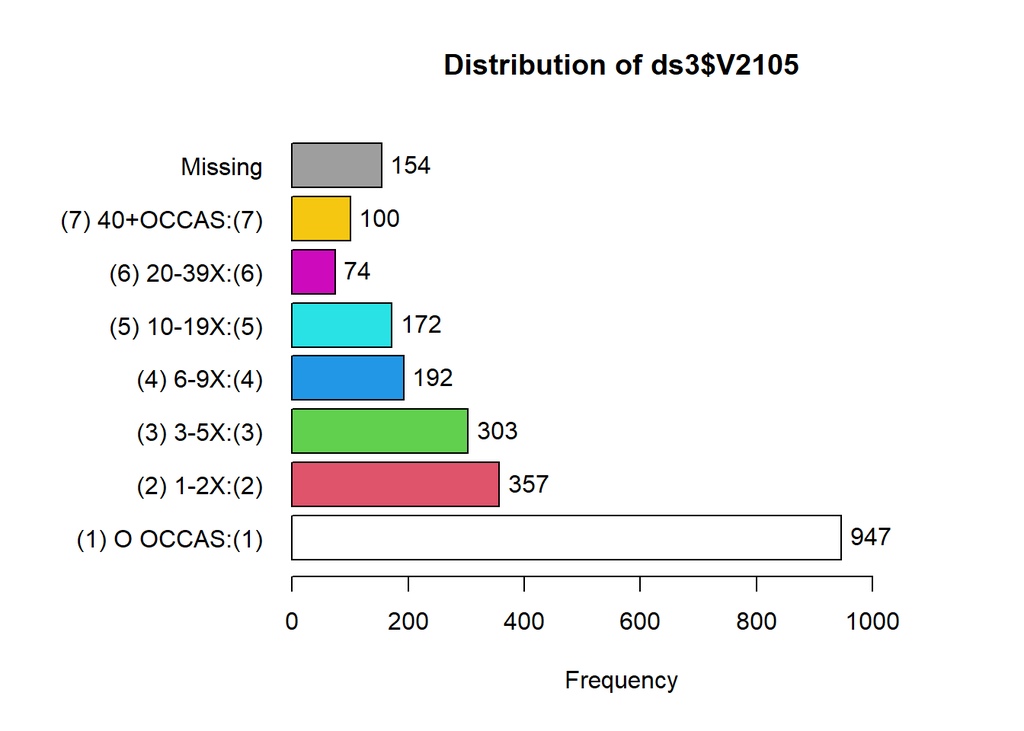

```
## ds3$V2105 :
##                  Frequency   %(NA+) cum.%(NA+)   %(NA-) cum.%(NA-)
## (1) O OCCAS:(1)        947     41.2       41.2     44.1       44.1
## (2) 1-2X:(2)           357     15.5       56.7     16.6       60.8
## (3) 3-5X:(3)           303     13.2       69.9     14.1       74.9
## (4) 6-9X:(4)           192      8.4       78.3      9.0       83.9
## (5) 10-19X:(5)         172      7.5       85.7      8.0       91.9
## (6) 20-39X:(6)          74      3.2       89.0      3.4       95.3
## (7) 40+OCCAS:(7)       100      4.3       93.3      4.7      100.0
## NA's                   154      6.7      100.0      0.0      100.0
##   Total               2299    100.0      100.0    100.0      100.0
```

```r
tab1(ds3$V2105, cum.percent = TRUE)
```

### 00860:#XMJ+HS/LAST12MO

On how many occasions (if any) have you used marijuana (grass, pot) or hashish (hash, hash oil) . . . during the last 12 months?

[For form 1, item is recoded from separate marijuana and hashish questions, and “Dope” is given as another example of what marijuana is called.]

1=“0 Occasions” 2=“1-2 Occasions” 3=“3-5 Occasions” 4=“6-9 Occasions” 5=“10-19 Occasions” 6=“20-39 Occasions” 7=“40 or More”

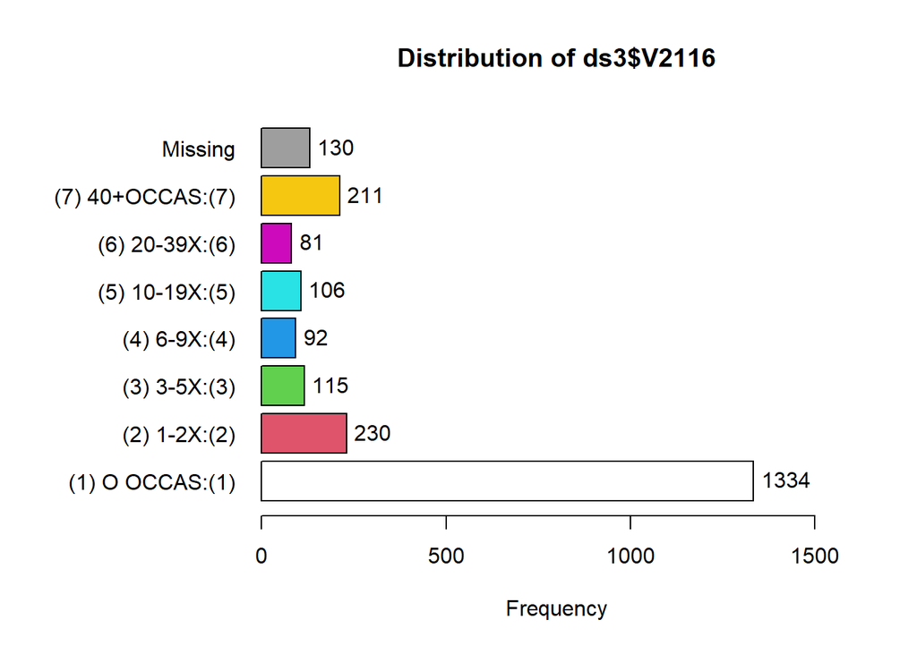

```
## ds3$V2116 :
##                  Frequency   %(NA+) cum.%(NA+)   %(NA-) cum.%(NA-)
## (1) O OCCAS:(1)       1334     58.0       58.0     61.5       61.5
## (2) 1-2X:(2)           230     10.0       68.0     10.6       72.1
## (3) 3-5X:(3)           115      5.0       73.0      5.3       77.4
## (4) 6-9X:(4)            92      4.0       77.0      4.2       81.7
## (5) 10-19X:(5)         106      4.6       81.6      4.9       86.5
## (6) 20-39X:(6)          81      3.5       85.2      3.7       90.3
## (7) 40+OCCAS:(7)       211      9.2       94.3      9.7      100.0
## NA's                   130      5.7      100.0      0.0      100.0
##   Total               2299    100.0      100.0    100.0      100.0
```

```r
tab1(ds3$V2116, cum.percent = TRUE)
```

### 00900:#X LSD/LAST 12MO

On how many occasions (if any) have you used LSD (“acid”) . . . during the last 12 months?

[Worded slightly differently in form 1; see form 1 codebook.]

1=“0 Occasions” 2=“1-2 Occasions” 3=“3-5 Occasions” 4=“6-9 Occasions” 5=“10-19 Occasions” 6=“20-39 Occasions” 7=“40 or More”

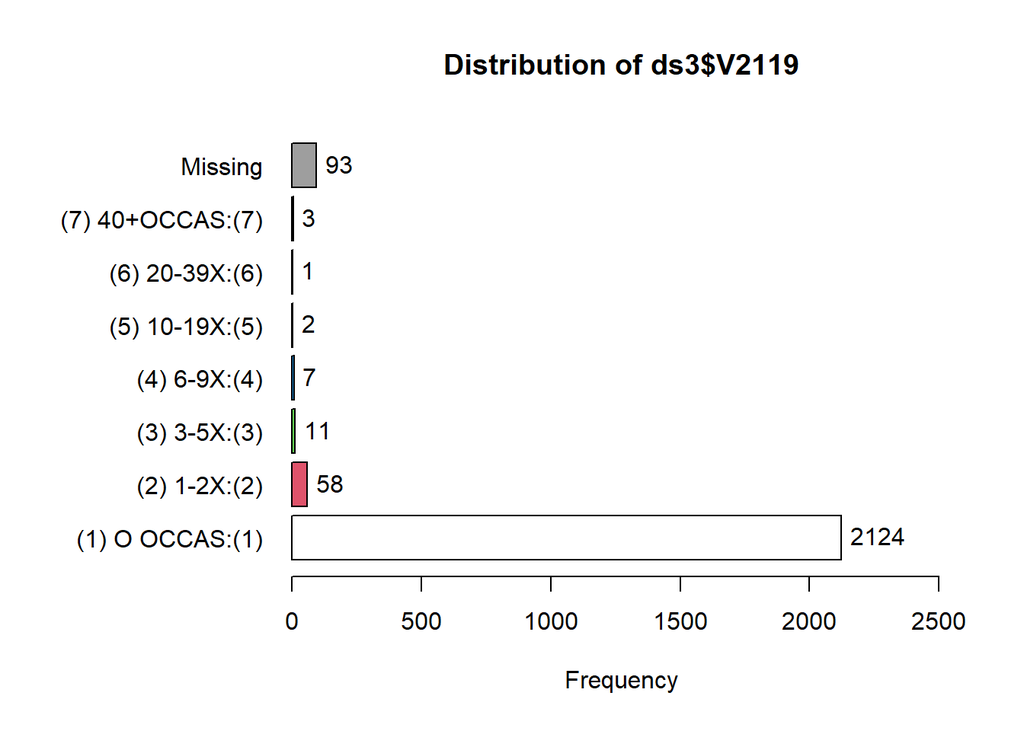

```
## ds3$V2119 :
##                  Frequency   %(NA+) cum.%(NA+)   %(NA-) cum.%(NA-)
## (1) O OCCAS:(1)       2124     92.4       92.4     96.3       96.3
## (2) 1-2X:(2)            58      2.5       94.9      2.6       98.9
## (3) 3-5X:(3)            11      0.5       95.4      0.5       99.4
## (4) 6-9X:(4)             7      0.3       95.7      0.3       99.7
## (5) 10-19X:(5)           2      0.1       95.8      0.1       99.8
## (6) 20-39X:(6)           1      0.0       95.8      0.0       99.9
## (7) 40+OCCAS:(7)         3      0.1       96.0      0.1      100.0
## NA's                    93      4.0      100.0      0.0      100.0
##   Total               2299    100.0      100.0    100.0      100.0
```

```r
tab1(ds3$V2119, cum.percent = TRUE)
```

### 00960:#X COKE/LAST12MO

On how many occasions (if any) have you taken cocaine (sometimes called “coke”, “crack”, “rock”) . . . during last 12 months?

[For questionnaire forms 1, 3, 4, and 6, item is recoded from separate questions about “crack” (items 22260-22280) and other forms of cocaine (items 22320-22340).]

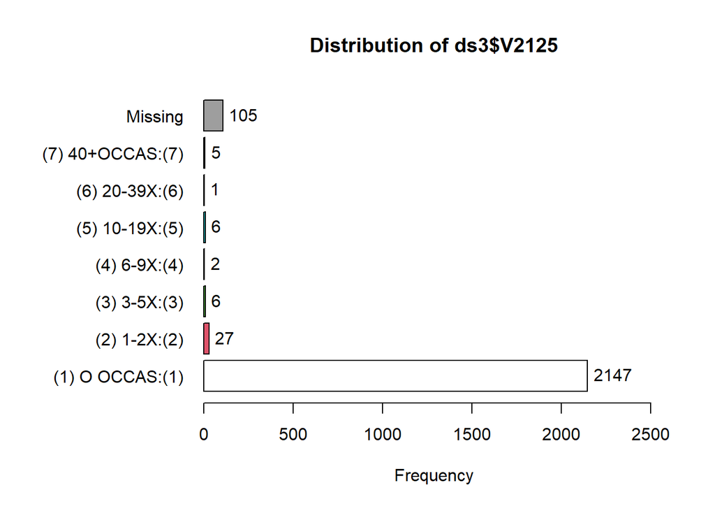

```
## ds3$V2125 :
##                  Frequency   %(NA+) cum.%(NA+)   %(NA-) cum.%(NA-)
## (1) O OCCAS:(1)       2147     93.4       93.4     97.9       97.9
## (2) 1-2X:(2)            27      1.2       94.6      1.2       99.1
## (3) 3-5X:(3)             6      0.3       94.8      0.3       99.4
## (4) 6-9X:(4)             2      0.1       94.9      0.1       99.5
## (5) 10-19X:(5)           6      0.3       95.2      0.3       99.7
## (6) 20-39X:(6)           1      0.0       95.2      0.0       99.8
## (7) 40+OCCAS:(7)         5      0.2       95.4      0.2      100.0
## NA's                   105      4.6      100.0      0.0      100.0
##   Total               2299    100.0      100.0    100.0      100.0
```

```r
tab1(ds3$V2125, cum.percent = TRUE)
```

### 00990:#X AMPH/LAST12MO

{Amphetamines are sometimes prescribed by doctors for people who have trouble paying attention, are hyperactive, have ADHD, or have trouble staying awake. They are sometimes called uppers, ups, pep pills, and include drugs like Adderall and Ritalin. Drugstores are not supposed to sell them without a prescription from a doctor. Amphetamines

do NOT include any nonprescription drugs, such as over-the-counter diet pills or stay-awake pills.

[Questionnaire form 1 worded somewhat differently and also includes as examples: Benzedrine, Dexedrine, Methedrine, Ritalin, Adderall, Concerta, Methamphetamine, Meth or Crystal Meth (see form 1 codebook).]}

[All forms]: On how many occasions (if any) have you taken amphetamines on your own–that is, without a doctor telling you to take them . . . during the last 12 months?

1=“0 Occasions” 2=“1-2 Occasions” 3=“3-5 Occasions” 4=“6-9 Occasions” 5=“10-19 Occasions” 6=“20-39 Occasions” 7=“40 or More”

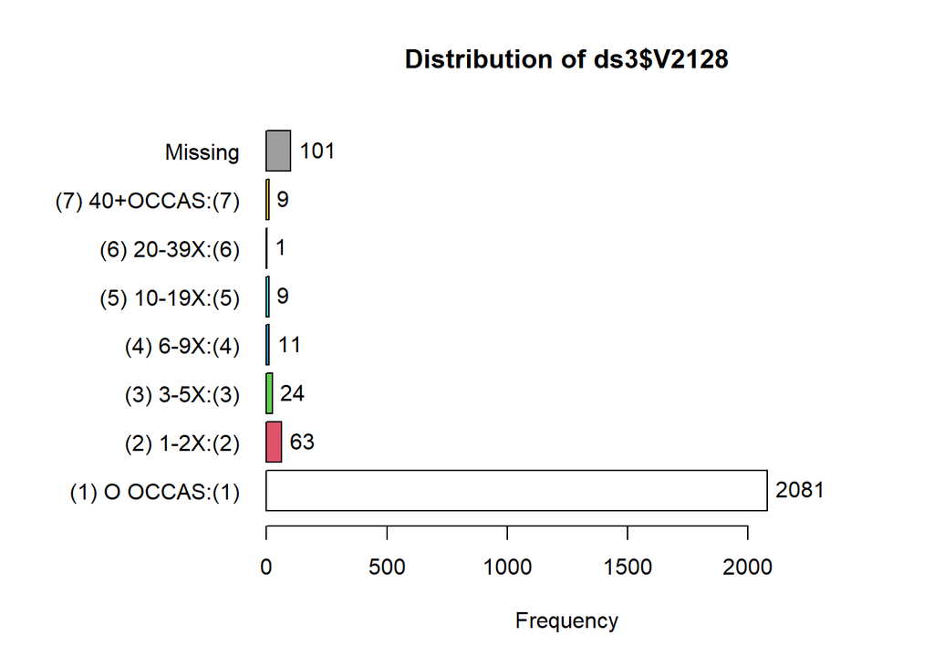

```
## ds3$V2128 :
##                  Frequency   %(NA+) cum.%(NA+)   %(NA-) cum.%(NA-)
## (1) O OCCAS:(1)       2081     90.5       90.5     94.7       94.7
## (2) 1-2X:(2)            63      2.7       93.3      2.9       97.5
## (3) 3-5X:(3)            24      1.0       94.3      1.1       98.6
## (4) 6-9X:(4)            11      0.5       94.8      0.5       99.1
## (5) 10-19X:(5)           9      0.4       95.2      0.4       99.5
## (6) 20-39X:(6)           1      0.0       95.2      0.0       99.6
## (7) 40+OCCAS:(7)         9      0.4       95.6      0.4      100.0
## NA's                   101      4.4      100.0      0.0      100.0
##   Total               2299    100.0      100.0    100.0      100.0
```

```r
tab1(ds3$V2128, cum.percent = TRUE)
```

### 01050:#X SED/BARB/LAST12MO

{Sedatives, including barbiturates, are sometimes prescribed by doctors to help people relax or get to sleep. They are sometimes called downs or downers, and include phenobarbital, Tuinal, Nembutal, and Seconal.} On how many occasions (if any) have you taken sedatives on your own–that is, without a doctor telling you to take them . . . during the last 12 months?

[Worded slightly differently in questionnaire form 1, and replaced Nembutal with Ambien, Lunesta, and Sonata as examples; see form 1 codebook.]

1=“0 Occasions” 2=“1-2 Occasions” 3=“3-5 Occasions” 4=“6-9 Occasions” 5=“10-19 Occasions” 6=“20-39 Occasions” 7=“40 or More”

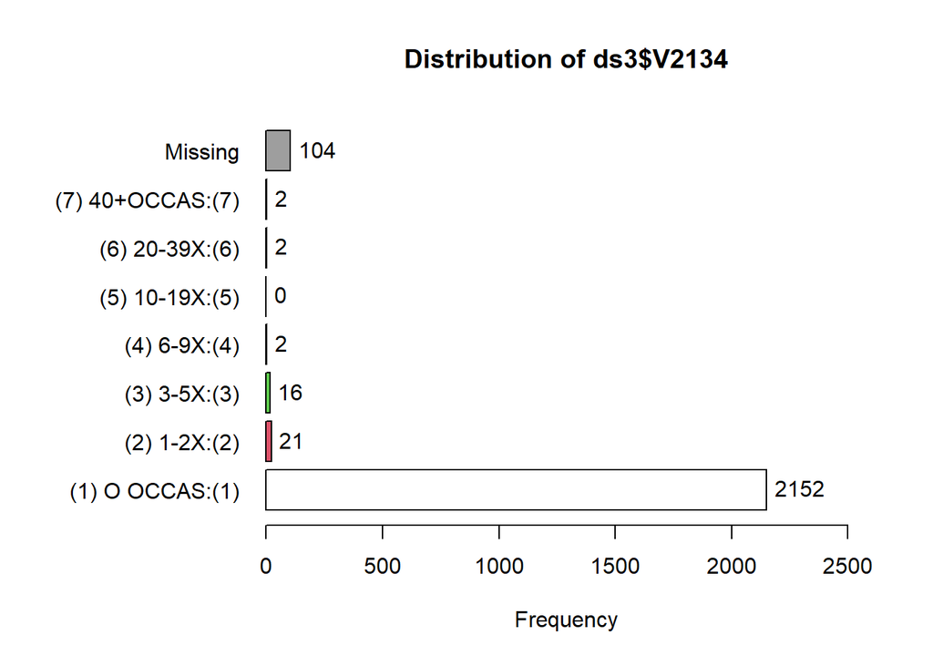

```
## ds3$V2134 :
##                  Frequency   %(NA+) cum.%(NA+)   %(NA-) cum.%(NA-)
## (1) O OCCAS:(1)       2152     93.6       93.6     98.0       98.0
## (2) 1-2X:(2)            21      0.9       94.5      1.0       99.0
## (3) 3-5X:(3)            16      0.7       95.2      0.7       99.7
## (4) 6-9X:(4)             2      0.1       95.3      0.1       99.8
## (5) 10-19X:(5)           0      0.0       95.3      0.0       99.8
## (6) 20-39X:(6)           2      0.1       95.4      0.1       99.9
## (7) 40+OCCAS:(7)         2      0.1       95.5      0.1      100.0
## NA's                   104      4.5      100.0      0.0      100.0
##   Total               2299    100.0      100.0    100.0      100.0
```

```r
tab1(ds3$V2134, cum.percent = TRUE)
```

### 01080:#X TRQL/LAST12MO

{Tranquilizers are sometimes prescribed by doctors to calm people down, quiet their nerves, or relax their muscles. Librium, Valium, and Xanax are all tranquilizers.} On how many occasions (if any) have you taken tranquilizers on your own–that is, without a doctor telling you to take them . . . during the last 12 months?

[Questionnaire form 1 worded somewhat differently and adds Soma, Serax, Ativan, Klonopin to the examples (see form 1 codebook).]

1=“0 Occasions” 2=“1-2 Occasions” 3=“3-5 Occasions” 4=“6-9 Occasions” 5=“10-19 Occasions” 6=“20-39 Occasions” 7=“40 or More”

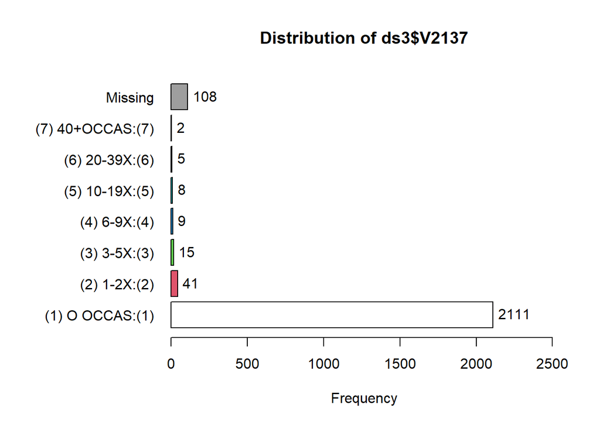

```
## ds3$V2137 :
##                  Frequency   %(NA+) cum.%(NA+)   %(NA-) cum.%(NA-)
## (1) O OCCAS:(1)       2111     91.8       91.8     96.3       96.3
## (2) 1-2X:(2)            41      1.8       93.6      1.9       98.2
## (3) 3-5X:(3)            15      0.7       94.3      0.7       98.9
## (4) 6-9X:(4)             9      0.4       94.6      0.4       99.3
## (5) 10-19X:(5)           8      0.3       95.0      0.4       99.7
## (6) 20-39X:(6)           5      0.2       95.2      0.2       99.9
## (7) 40+OCCAS:(7)         2      0.1       95.3      0.1      100.0
## NA's                   108      4.7      100.0      0.0      100.0
##   Total               2299    100.0      100.0    100.0      100.0
```

```r
tab1(ds3$V2137, cum.percent = TRUE)
```

### 01110:#X ‘H’/LAST 12MO

On how many occasions (if any) have you taken heroin . . . during the last 12 months?

[For questionnaire forms 2, 5, and 6, item is recoded from separate questions about heroin use with a needle (items 29630-29650) and without a needle (items 29660-29680).]

1=“0 Occasions” 2=“1-2 Occasions” 3=“3-5 Occasions” 4=“6-9 Occasions” 5=“10-19 Occasions” 6=“20-39 Occasions” 7=“40 or More”

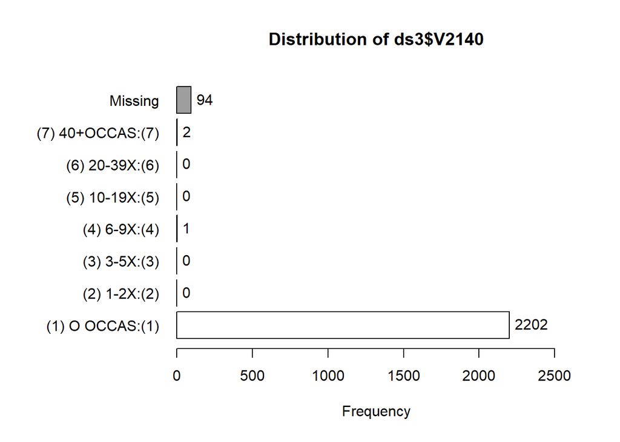

```
## ds3$V2140 :
##                  Frequency   %(NA+) cum.%(NA+)   %(NA-) cum.%(NA-)
## (1) O OCCAS:(1)       2202     95.8       95.8     99.9       99.9
## (2) 1-2X:(2)             0      0.0       95.8      0.0       99.9
## (3) 3-5X:(3)             0      0.0       95.8      0.0       99.9
## (4) 6-9X:(4)             1      0.0       95.8      0.0       99.9
## (5) 10-19X:(5)           0      0.0       95.8      0.0       99.9
## (6) 20-39X:(6)           0      0.0       95.8      0.0       99.9
## (7) 40+OCCAS:(7)         2      0.1       95.9      0.1      100.0
## NA's                    94      4.1      100.0      0.0      100.0
##   Total               2299    100.0      100.0    100.0      100.0
```

```r
tab1(ds3$V2140, cum.percent = TRUE)
```

### 01140:#X NARC/LAST12MO

{There are a number of narcotics other than heroin, such as methadone, opium, morphine, codeine, Demerol, Vicodin, OxyContin, and Percocet. These are sometimes prescribed by doctors.} On how many occasions (if any) have you taken narcotics other than heroin on your own–that is, without a doctor telling you to take them . . . during the last 12 months?

[Questionnaire form 1 worded somewhat differently and adds “Percodan, Ultram” (see form 1 Codebook).]

1=“0 Occasions” 2=“1-2 Occasions” 3=“3-5 Occasions” 4=“6-9 Occasions” 5=“10-19 Occasions” 6=“20-39 Occasions” 7=“40 or More”

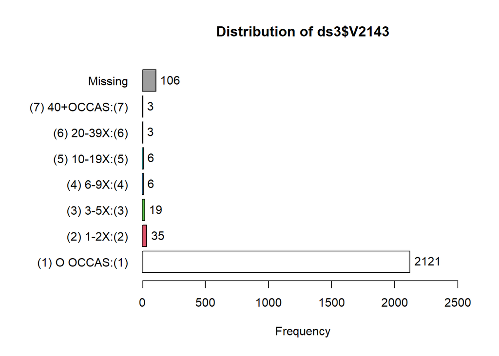

```
## ds3$V2143 :
##                  Frequency   %(NA+) cum.%(NA+)   %(NA-) cum.%(NA-)
## (1) O OCCAS:(1)       2121     92.3       92.3     96.7       96.7
## (2) 1-2X:(2)            35      1.5       93.8      1.6       98.3
## (3) 3-5X:(3)            19      0.8       94.6      0.9       99.2
## (4) 6-9X:(4)             6      0.3       94.9      0.3       99.5
## (5) 10-19X:(5)           6      0.3       95.1      0.3       99.7
## (6) 20-39X:(6)           3      0.1       95.3      0.1       99.9
## (7) 40+OCCAS:(7)         3      0.1       95.4      0.1      100.0
## NA's                   106      4.6      100.0      0.0      100.0
##   Total               2299    100.0      100.0    100.0      100.0
```

```r
tab1(ds3$V2143, cum.percent = TRUE)
```

### 00170:#X INHL/LAST12MO

On how many occasions (if any) have you sniffed glue, or breathed the contents of aerosol spray cans, or inhaled any other gases or sprays in order to get high . . . during the last 12 months?

1=“0 Occasions” 2=“1-2 Occasions” 3=“3-5 Occasions” 4=“6-9 Occasions” 5=“10-19 Occasions” 6=“20-39 Occasions” 7=“40 or More”

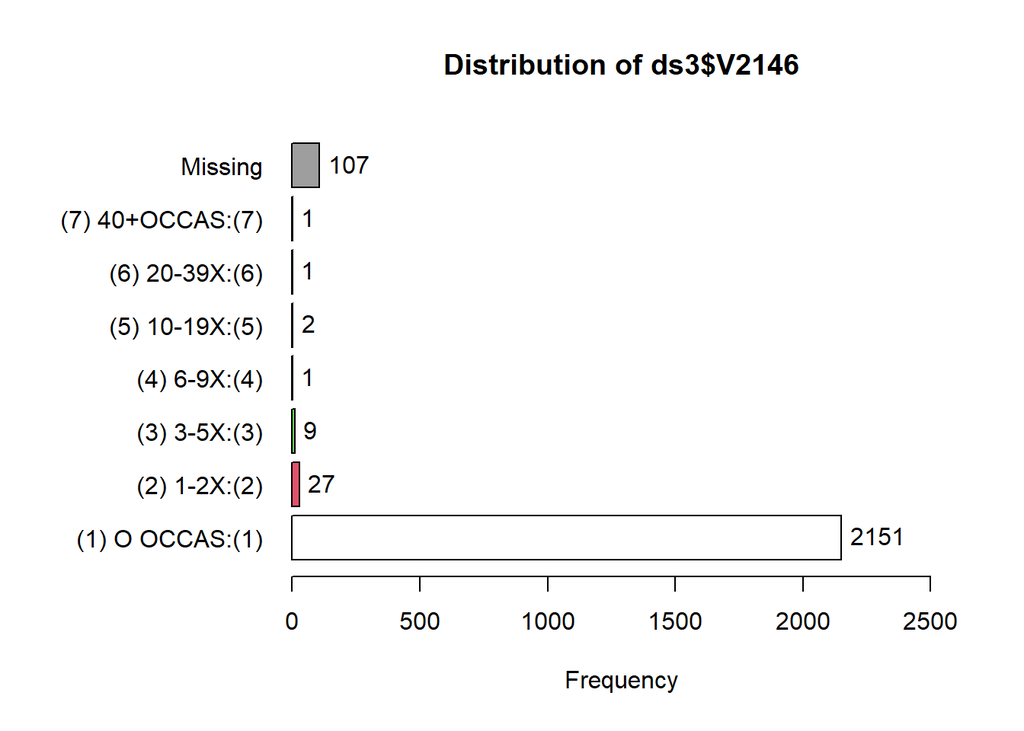

```
## ds3$V2146 :
##                  Frequency   %(NA+) cum.%(NA+)   %(NA-) cum.%(NA-)
## (1) O OCCAS:(1)       2151     93.6       93.6     98.1       98.1
## (2) 1-2X:(2)            27      1.2       94.7      1.2       99.4
## (3) 3-5X:(3)             9      0.4       95.1      0.4       99.8
## (4) 6-9X:(4)             1      0.0       95.2      0.0       99.8
## (5) 10-19X:(5)           2      0.1       95.3      0.1       99.9
## (6) 20-39X:(6)           1      0.0       95.3      0.0      100.0
## (7) 40+OCCAS:(7)         1      0.0       95.3      0.0      100.0
## NA's                   107      4.7      100.0      0.0      100.0
##   Total               2299    100.0      100.0    100.0      100.0
```

```r
tab1(ds3$V2146, cum.percent = TRUE)
```

### 35150:#DAYS VAPE NIC/12MO

On how many DAYS (if any) have you vaped NICOTINE . . . during the last 12 months?

1=“0 Days” 2=“1-2 Days” 3=“3-5 Days” 4=“6-9 Days” 5=“10-19 Days” 6=“20 or More”

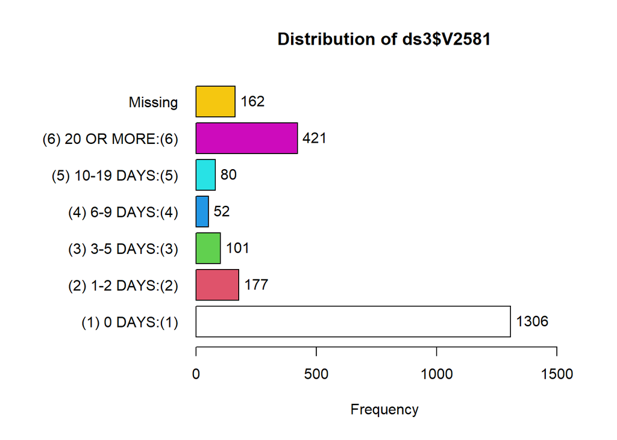

```
## ds3$V2581 :
##                    Frequency   %(NA+) cum.%(NA+)   %(NA-) cum.%(NA-)
## (1) 0 DAYS:(1)          1306     56.8       56.8     61.1       61.1
## (2) 1-2 DAYS:(2)         177      7.7       64.5      8.3       69.4
## (3) 3-5 DAYS:(3)         101      4.4       68.9      4.7       74.1
## (4) 6-9 DAYS:(4)          52      2.3       71.2      2.4       76.6
## (5) 10-19 DAYS:(5)        80      3.5       74.6      3.7       80.3
## (6) 20 OR MORE:(6)       421     18.3       93.0     19.7      100.0
## NA's                     162      7.0      100.0      0.0      100.0
##   Total                 2299    100.0      100.0    100.0      100.0
```

```r
tab1(ds3$V2581, cum.percent = TRUE)
```

### V2584: 35180:#DAYS VAPE MJ/12MO

On how many DAYS (if any) have you vaped MARIJUANA . . . during the last 12 months?

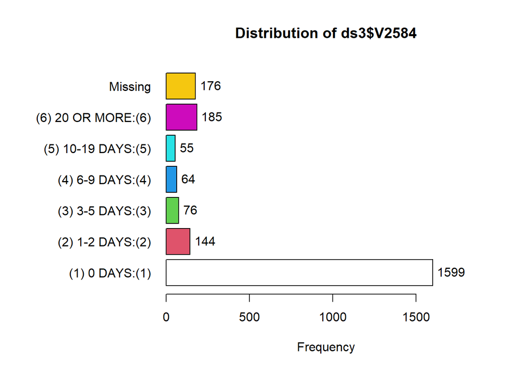

```
## ds3$V2584 :
##                    Frequency   %(NA+) cum.%(NA+)   %(NA-) cum.%(NA-)
## (1) 0 DAYS:(1)          1599     69.6       69.6     75.3       75.3
## (2) 1-2 DAYS:(2)         144      6.3       75.8      6.8       82.1
## (3) 3-5 DAYS:(3)          76      3.3       79.1      3.6       85.7
## (4) 6-9 DAYS:(4)          64      2.8       81.9      3.0       88.7
## (5) 10-19 DAYS:(5)        55      2.4       84.3      2.6       91.3
## (6) 20 OR MORE:(6)       185      8.0       92.3      8.7      100.0
## NA's                     176      7.7      100.0      0.0      100.0
##   Total                 2299    100.0      100.0    100.0      100.0
```

```r
tab1(ds3$V2584, cum.percent = TRUE)
```

## Aggregating them Together

# Composite Variable Report

In this composite variable, 0 means have no substance use at all, 1 means having 1 type of substance use history, 2 means having 2 types of substance use history, and it goes on. All NAs are retained.

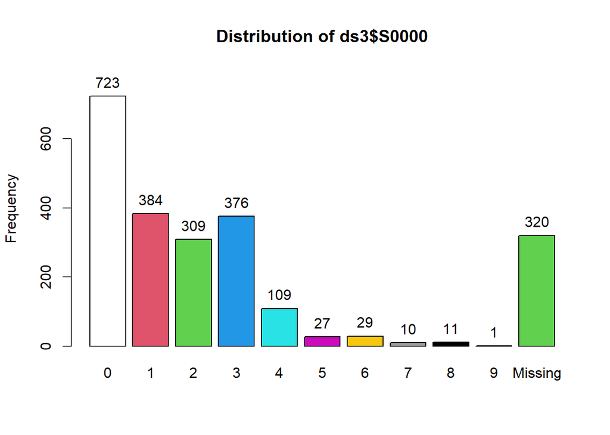

```
## ds3$S0000 :
##         Frequency   %(NA+) cum.%(NA+)   %(NA-) cum.%(NA-)
## 0             723     31.4       31.4     36.5       36.5
## 1             384     16.7       48.2     19.4       55.9
## 2             309     13.4       61.6     15.6       71.6
## 3             376     16.4       77.9     19.0       90.6
## 4             109      4.7       82.7      5.5       96.1
## 5              27      1.2       83.9      1.4       97.4
## 6              29      1.3       85.1      1.5       98.9
## 7              10      0.4       85.6      0.5       99.4
## 8              11      0.5       86.0      0.6       99.9
## 9               1      0.0       86.1      0.1      100.0
## <NA>          320     13.9      100.0      0.0      100.0
##   Total      2299    100.0      100.0    100.0      100.0
```

```r
library(dplyr)

# Create Numerical Dichotomous Variables
ds3$V2105D<-ifelse(ds3$V2105=="(1) O OCCAS:(1)",0,1)
ds3$V2116D<-ifelse(ds3$V2116=="(1) O OCCAS:(1)",0,1)
ds3$V2119D<-ifelse(ds3$V2119=="(1) O OCCAS:(1)",0,1)
ds3$V2125D<-ifelse(ds3$V2125=="(1) O OCCAS:(1)",0,1)
ds3$V2128D<-ifelse(ds3$V2128=="(1) O OCCAS:(1)",0,1)
ds3$V2134D<-ifelse(ds3$V2134=="(1) O OCCAS:(1)",0,1)
ds3$V2137D<-ifelse(ds3$V2137=="(1) O OCCAS:(1)",0,1)
ds3$V2140D<-ifelse(ds3$V2140=="(1) O OCCAS:(1)",0,1)
ds3$V2143D<-ifelse(ds3$V2143=="(1) O OCCAS:(1)",0,1)
ds3$V2146D<-ifelse(ds3$V2146=="(1) O OCCAS:(1)",0,1)
ds3$V2581D<-ifelse(ds3$V2581=="(1) 0 DAYS:(1)",0,1)



# Sum these dichotomous
ds3$S0000 <- ds3$V2105D + ds3$V2116D + ds3$V2119D + ds3$V2125D + ds3$V2128D + ds3$V2134D + ds3$V2137D + ds3$V2140D + ds3$V2143D + ds3$V2146D + ds3$V2581D

# Showing the distribution of the new composite variable
tab1(ds3$S0000, cum.percent = TRUE)
```

Let’s take each of them out of our composite variable SOOOO.

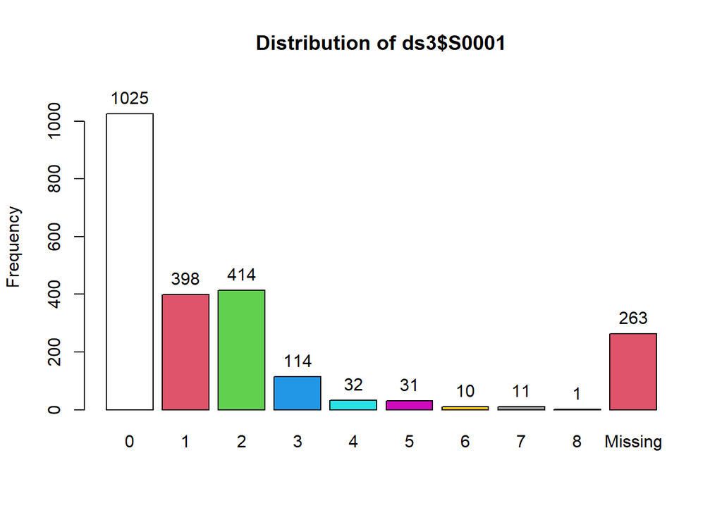

```
## ds3$S0001 :
##         Frequency   %(NA+) cum.%(NA+)   %(NA-) cum.%(NA-)
## 0            1025     44.6       44.6     50.3       50.3
## 1             398     17.3       61.9     19.5       69.9
## 2             414     18.0       79.9     20.3       90.2
## 3             114      5.0       84.9      5.6       95.8
## 4              32      1.4       86.3      1.6       97.4
## 5              31      1.3       87.6      1.5       98.9
## 6              10      0.4       88.0      0.5       99.4
## 7              11      0.5       88.5      0.5      100.0
## 8               1      0.0       88.6      0.0      100.0
## <NA>          263     11.4      100.0      0.0      100.0
##   Total      2299    100.0      100.0    100.0      100.0
```

```r
ds3$S0001 <- ds3$V2116D + ds3$V2119D + ds3$V2125D + ds3$V2128D + ds3$V2134D + ds3$V2137D + ds3$V2140D + ds3$V2143D + ds3$V2146D + ds3$V2581D

# Showing the distribution of the new composite variable
tab1(ds3$S0001, cum.percent = TRUE)
```

Then, let’s take out V2581 Vaping, creating the composite S0002

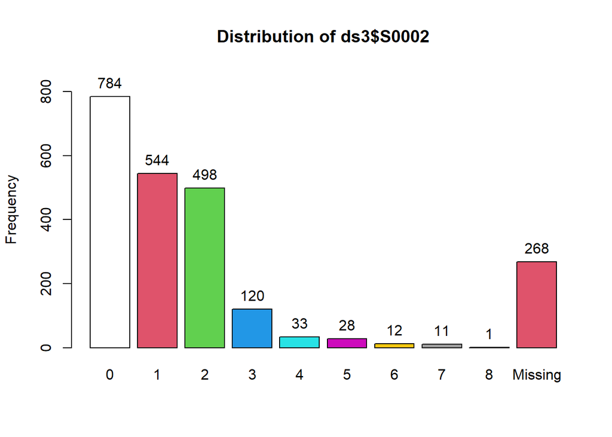

```
## ds3$S0002 :
##         Frequency   %(NA+) cum.%(NA+)   %(NA-) cum.%(NA-)
## 0             784     34.1       34.1     38.6       38.6
## 1             544     23.7       57.8     26.8       65.4
## 2             498     21.7       79.4     24.5       89.9
## 3             120      5.2       84.6      5.9       95.8
## 4              33      1.4       86.1      1.6       97.4
## 5              28      1.2       87.3      1.4       98.8
## 6              12      0.5       87.8      0.6       99.4
## 7              11      0.5       88.3      0.5      100.0
## 8               1      0.0       88.3      0.0      100.0
## <NA>          268     11.7      100.0      0.0      100.0
##   Total      2299    100.0      100.0    100.0      100.0
```

```r
ds3$S0002 <- ds3$V2105D + ds3$V2116D + ds3$V2119D + ds3$V2125D + ds3$V2128D + ds3$V2134D + ds3$V2137D + ds3$V2140D + ds3$V2143D + ds3$V2146D

# Showing the distribution of the new composite variable
tab1(ds3$S0002, cum.percent = TRUE)
```

Finally, Let’s take out both V2105 and V2581, and make the composite variable S0003:

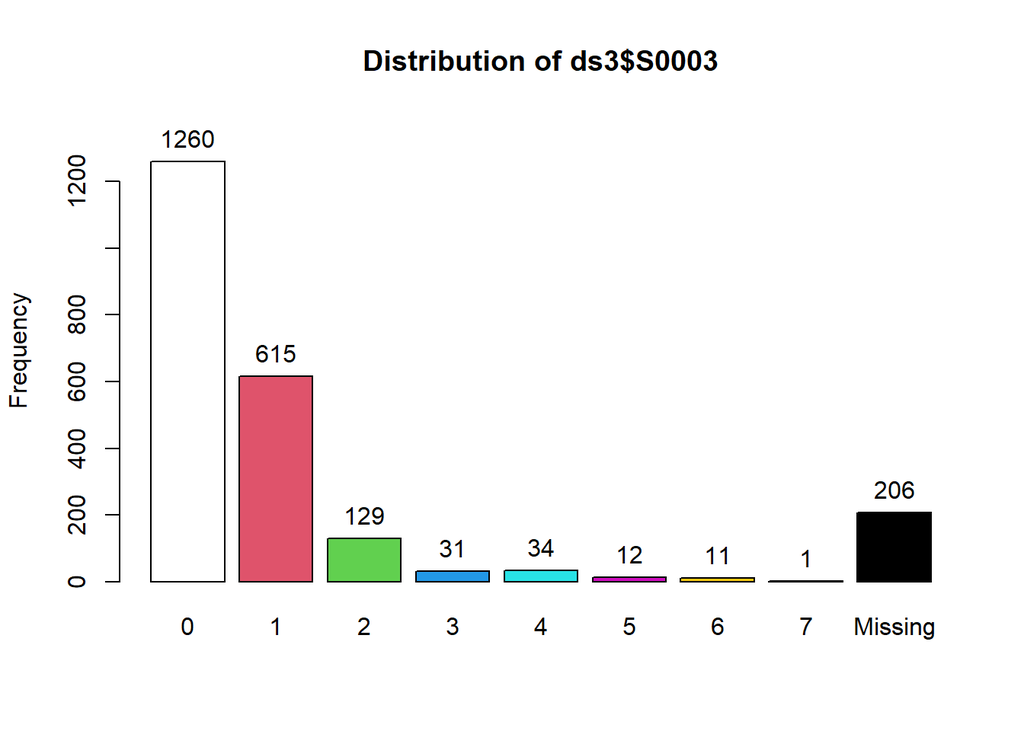

```
## ds3$S0003 :
##         Frequency   %(NA+) cum.%(NA+)   %(NA-) cum.%(NA-)
## 0            1260     54.8       54.8     60.2       60.2
## 1             615     26.8       81.6     29.4       89.6
## 2             129      5.6       87.2      6.2       95.7
## 3              31      1.3       88.5      1.5       97.2
## 4              34      1.5       90.0      1.6       98.9
## 5              12      0.5       90.5      0.6       99.4
## 6              11      0.5       91.0      0.5      100.0
## 7               1      0.0       91.0      0.0      100.0
## <NA>          206      9.0      100.0      0.0      100.0
##   Total      2299    100.0      100.0    100.0      100.0
```

```r
ds3$S0003 <- ds3$V2116D + ds3$V2119D + ds3$V2125D + ds3$V2128D + ds3$V2134D + ds3$V2137D + ds3$V2140D + ds3$V2143D + ds3$V2146D

# Showing the distribution of the new composite variable
tab1(ds3$S0003, cum.percent = TRUE)
```